# Data_mining

Alexis REMOND

19/01/2022

Nous installons d’abord tous les packages dont l’on aura besoin lors de notre analyse de la base de données.

```r
.libPaths("D:/2ème année/s3/R/Packages R")
library(tidyverse)
library(car)
```

```r
library(tibble)
library(forcats)
library(ggplot2)
library(readr)
library(dplyr)
library(FactoMineR)
library(factoextra)
library(ggeffects)
library(effects)
```

Lors de notre Tp de Data mining, nous devions analyser les difficultés financières des exploitations agricoles. Nous disposons d’un jeu de données constitué de 1 260 exploitations issues des départements de l’Eure-27 (348 exploitations), du Nord-59 (282 exploitations), de l’Orne-61 (333 exploitations), et de la Seine-Maritime-76 (297 exploitations) comparables dans leurs productions agricoles dominantes car spécialisées pour la plupart dans les grandes cultures. Les sous-échantillons sont équilibrés dans leur effectif et l’observation réalisée couvre la période 1988 à 1994. On dispose notamment de la variable indicateur de difficulté financière. On dispose aussi d’une batterie de critères économiques et financiers comprenant 22 ratios sélectionnés selon les thématiques suivantes : • Capitalisation – r1 dette totale / actif total ; – r2 capitaux propres / capital investi ; – r3 dette à court terme / dette totale ; – r4 dette à court terme/total de l’actif ; – r5 dette à long et moyen terme / total de l’actif ; • Poids de la dette – r6 dette totale / produit brut ; – r7 dette long et moyen terme / produit brut ; – r8 dette à court terme / produit brut ; • Liquidité – r11 fonds de roulement / produit brut ; – r12 fonds de roulement / (intrants réels - frais financiers) ; – r14 dette à court terme / actifs circulants ; • Service de la dette – r17 frais financiers / dette totale ; – r18 frais financiers / produit brut ; – r19 (frais financiers + remboursement du capital long et moyen terme) / produit brut ; – r21 charges financières / EBITDA ; – r22 (charges financières + remboursement du capital long et moyen terme)/EBITDA ; • Rentabilité du capital – r24 EBITDA /total de l’actif ; • Bénéfice – r28 EBITDA / produit brut ; – r30 revenu disponible / produit brut ; – r32 (EBITDA - frais financiers) / produit brut ; • Activité productive – r36 actifs immobilisés / produit brut ; – r37 produit brut / actif total.

Non avons pour objectif d’analyser les causes de difficulté financière des exploitations agricoles, de trouver un modèle permettant d’identifier les exploitations agricoles en difficulté financière afin de les prévenir. Puis faire un rapport écrit et oral de nos résultats.

On importe la base de données, qui nous a été donné par Madame GEY, notre professeur de Data Mining, au format csv

```r
#donnee$DIFF<-factor(donnee$DIFF,labels=c("Pas difficultés", "Difficultés"))

#colnames(donnee)<-c("Incident de payement","dette totale / actif total","capitaux propres / capital investi", "dette #à court terme / dette totale","dette à court terme/total de l’actif ","dette à long et moyen terme / total de #l’actif ", "dette totale / produit brut","dette long et moyen terme / produit brut ", "dette à court terme / produit #brut", "fonds de roulement / produit brut","fonds de roulement / (intrants réels - frais financiers) ","dette à #court terme / actifs circulants ","frais financiers / dette totale", "frais financiers / produit brut","(frais #financiers + remboursement du capital long et moyen terme) / produit brut ","charges financières / EBITDA","(charges #financières + remboursement du capital long et moyen terme)/EBITDA","EBITDA /total de l’actif"," EBITDA / produit #brut"," revenu disponible / produit brut","(EBITDA - frais financiers) / produit brut ", " actifs immobilisés / #produit brut ","produit brut / actif total")
```

On met ces instructions entre parenthèses car elles permettent de changer le nom des variables. Dans notre base de données, les noms des variables sont trop longs, il est préférable de laisser comme tel.

On regarde avec la fonction is.na() le nombre de valeur manquante.

```r
sum(is.na(donnee))
```

```
## [1] 0
```

On voit qu’il y a 0 valeur manquante dans la base de données

On peut regarder à quoi ressemble notre jeu de données, avec le minimum, le premier quartile, la mediane, la moyenne, le troisième quartile et le maximum.

```r
summary(donnee)
```

```
##       DIFF              R1               R2               R3
##  Min.   :0.0000   Min.   :0.1190   Min.   :0.0000   Min.   :-1.5060
##  1st Qu.:0.0000   1st Qu.:0.3450   1st Qu.:0.3200   1st Qu.: 0.2167
##  Median :0.0000   Median :0.5315   Median :0.5700   Median : 0.3573
##  Mean   :0.4817   Mean   :0.5833   Mean   :0.5212   Mean   : 0.3731
##  3rd Qu.:1.0000   3rd Qu.:0.7805   3rd Qu.:0.7550   3rd Qu.: 0.5165
##  Max.   :1.0000   Max.   :3.4940   Max.   :0.9980   Max.   : 0.9999
##        R4                 R5                R6              R7
##  Min.   :-0.49400   Min.   :0.00006   Min.   :0.180   Min.   :0.00005
##  1st Qu.: 0.07925   1st Qu.:0.20500   1st Qu.:0.573   1st Qu.:0.32975
##  Median : 0.15860   Median :0.33100   Median :0.919   Median :0.55850
##  Mean   : 0.22517   Mean   :0.35608   Mean   :1.047   Mean   :0.65602
##  3rd Qu.: 0.32215   3rd Qu.:0.47150   3rd Qu.:1.365   3rd Qu.:0.87600
##  Max.   : 1.11140   Max.   :2.79200   Max.   :4.362   Max.   :3.11700
##        R8               R11                 R12                R14
##  Min.   :-0.9330   Min.   :-0.906000   Min.   :-1.16300   Min.   :-0.6850
##  1st Qu.: 0.1371   1st Qu.:-0.007698   1st Qu.:-0.01098   1st Qu.: 0.2168
##  Median : 0.2846   Median : 0.288600   Median : 0.43910   Median : 0.4637
##  Mean   : 0.3836   Mean   : 0.271290   Mean   : 0.43993   Mean   : 0.6960
##  3rd Qu.: 0.5504   3rd Qu.: 0.543325   3rd Qu.: 0.86045   3rd Qu.: 1.0148
##  Max.   : 1.8494   Max.   : 2.308300   Max.   : 3.97150   Max.   : 5.1712
##       R17               R18               R19              R21
##  Min.   :0.00599   Min.   :0.00169   Min.   :0.0170   Min.   :0.00663
##  1st Qu.:0.04480   1st Qu.:0.03050   1st Qu.:0.0999   1st Qu.:0.08885
##  Median :0.06215   Median :0.05680   Median :0.1565   Median :0.17400
##  Mean   :0.06439   Mean   :0.07060   Mean   :0.1821   Mean   :0.27997
##  3rd Qu.:0.08170   3rd Qu.:0.09552   3rd Qu.:0.2320   3rd Qu.:0.34125
##  Max.   :0.19400   Max.   :0.30000   Max.   :1.6520   Max.   :5.07900
##       R22                R24              R28              R30
##  Min.   : 0.04939   Min.   :0.0141   Min.   :0.0347   Min.   :-1.22500
##  1st Qu.: 0.29142   1st Qu.:0.1350   1st Qu.:0.2600   1st Qu.: 0.05424
##  Median : 0.49370   Median :0.1860   Median :0.3270   Median : 0.16315
##  Mean   : 0.69876   Mean   :0.1960   Mean   :0.3217   Mean   : 0.13943
##  3rd Qu.: 0.81393   3rd Qu.:0.2432   3rd Qu.:0.3890   3rd Qu.: 0.25990
##  Max.   :13.67300   Max.   :0.7460   Max.   :0.7100   Max.   : 0.58700
##       R32               R36              R37
##  Min.   :-0.1620   Min.   :0.0000   Min.   :0.1600
##  1st Qu.: 0.1724   1st Qu.:0.7905   1st Qu.:0.4600
##  Median : 0.2667   Median :1.1000   Median :0.5750
##  Mean   : 0.2510   Mean   :1.1826   Mean   :0.6109
##  3rd Qu.: 0.3377   3rd Qu.:1.4725   3rd Qu.:0.7180
##  Max.   : 0.6608   Max.   :5.0430   Max.   :2.3490
```

```r
knitr::kable(head(donnee))
```

| DIFF | R1 | R2 | R3 | R4 | R5 | R6 | R7 | R8 | R11 | R12 | R14 | R17 | R18 | R19 | R21 | R22 | R24 | R28 | R30 | R32 | R36 | R37 |
| --- | --- | --- | --- | --- | --- | --- | --- | --- | --- | --- | --- | --- | --- | --- | --- | --- | --- | --- | --- | --- | --- | --- |
| 0 | 0.449 | 0.622 | 0.2550 | 0.11450 | 0.334 | 0.785 | 0.585 | 0.2002 | 0.6628 | 1.3698 | 0.2320 | 0.0884 | 0.0694 | 0.1660 | 0.1340 | 0.3219 | 0.295 | 0.475 | 0.3500 | 0.4313 | 0.886 | 0.572 |
| 0 | 0.450 | 0.617 | 0.2411 | 0.10840 | 0.341 | 0.518 | 0.393 | 0.1250 | 0.7098 | 1.2534 | 0.1497 | 0.0671 | 0.0348 | 0.1360 | 0.0802 | 0.3133 | 0.365 | 0.434 | 0.2978 | 0.3989 | 0.351 | 0.867 |
| 0 | 0.332 | 0.819 | 0.5568 | 0.18510 | 0.147 | 0.700 | 0.310 | 0.3895 | 0.4142 | 0.6370 | 0.4847 | 0.0445 | 0.0311 | 0.1030 | 0.0890 | 0.2945 | 0.166 | 0.350 | 0.2468 | 0.3187 | 1.300 | 0.475 |
| 0 | 0.363 | 0.733 | 0.3596 | 0.13050 | 0.232 | 0.773 | 0.495 | 0.2779 | 0.4661 | 1.0698 | 0.3735 | 0.0621 | 0.0480 | 0.1080 | 0.0851 | 0.1909 | 0.265 | 0.475 | 0.3759 | 0.4313 | 1.385 | 0.470 |
| 0 | 0.440 | 0.650 | 0.3142 | 0.13820 | 0.302 | 0.846 | 0.580 | 0.2658 | 0.7715 | 1.4752 | 0.2563 | 0.0489 | 0.0414 | 0.1270 | 0.0838 | 0.2567 | 0.257 | 0.475 | 0.3669 | 0.4313 | 0.886 | 0.520 |
| 0 | 0.306 | 0.755 | 0.2635 | 0.08055 | 0.225 | 0.709 | 0.523 | 0.1870 | 0.8178 | 1.4682 | 0.1861 | 0.0243 | 0.0173 | 0.0652 | 0.0390 | 0.1472 | 0.191 | 0.443 | 0.3759 | 0.4257 | 1.316 | 0.431 |

## 2.1 Statistique univariée

Nous allons commencer notre étude par une analyse univariée ### 2.1.1 Variables qualitatives

On démarre par la variable qualitative, il n’y en a qu’une seule et c’est la variable DIFF

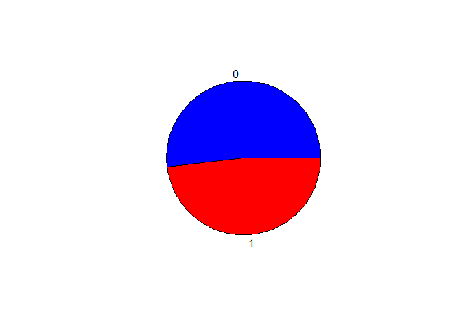

```r
p1 = prop.table(table(donnee$DIFF))
pie(p1, col = c("blue","red"))
```

On peut voir sur ce diagramme circulaire qu’il y a plus d’exploitation qui non pas de difficulté financière.

### 2.1.2 Variables quantitatives

On continue par les variables quantitatives, qui constituent le reste de notre base de données

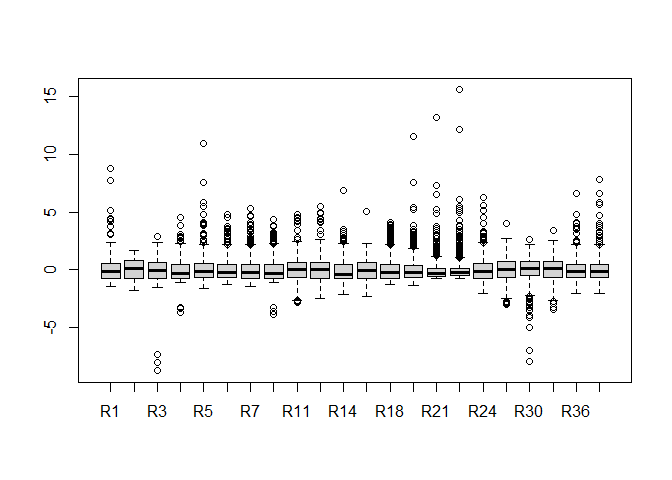

```r
donnees_quanti=donnee[,-1]
donnees_quanti_cr=scale(donnees_quanti)

boxplot(donnees_quanti_cr)
```

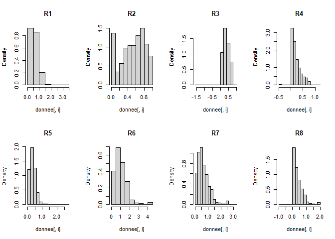

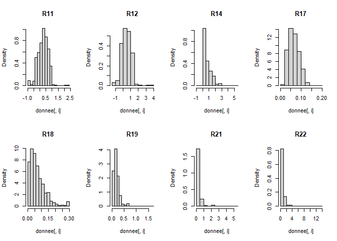

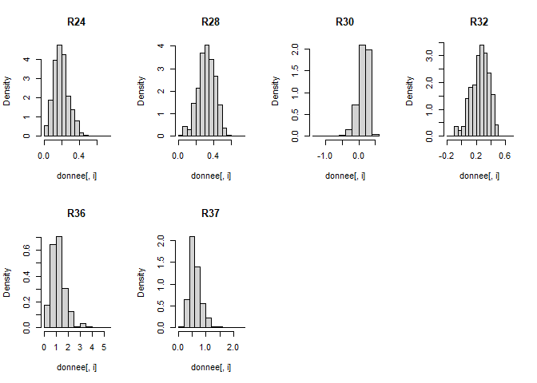

```r
sequence=2:23
par(mfrow = c(2,4))
for(i in sequence){
  hist(donnee[ , i],
       prob = TRUE,
       main = colnames(donnee)[i])
}
```

## 2.2 Statistique bivariée

### 2.2.1 Variables quantitatives et qualitative

On décide aussi de faire une analyse bivariée de la variable DIFF par rapport aux autres variables. Les diagrammes représentés sont des boîtes à moustaches

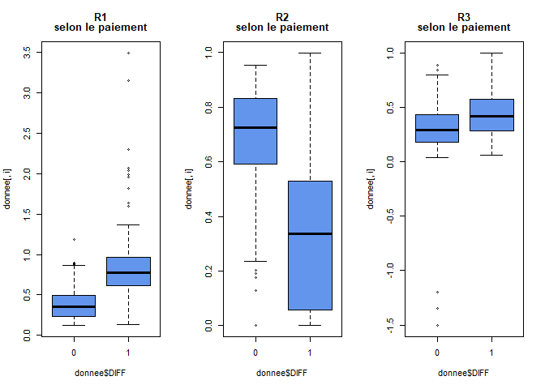

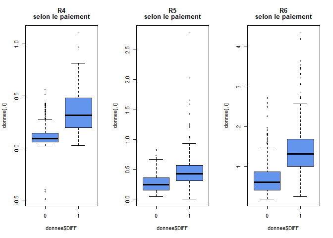

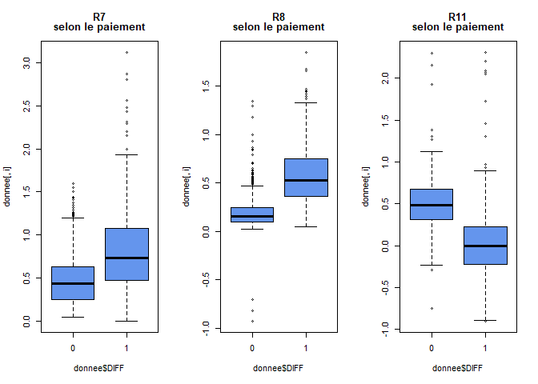

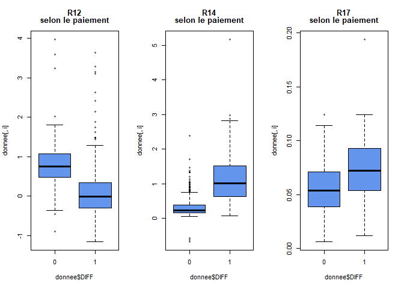

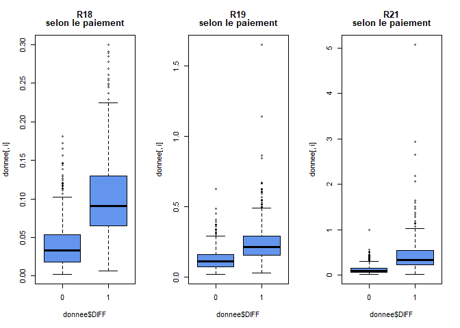

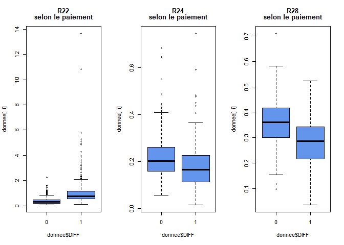

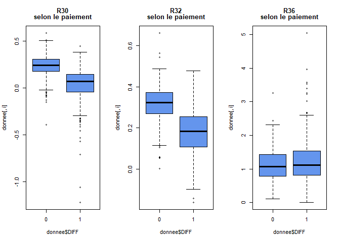

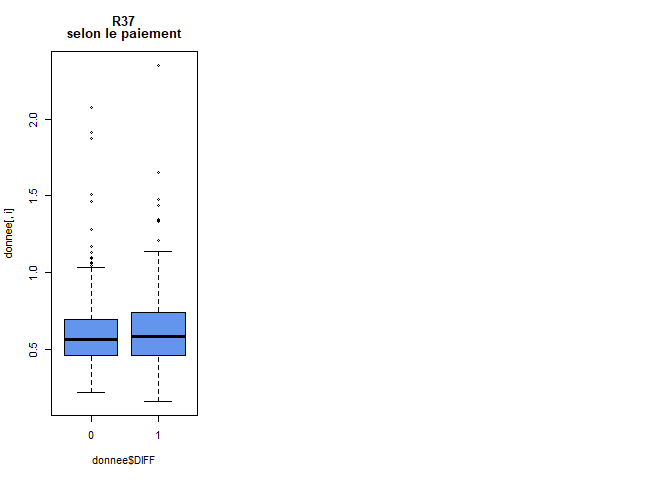

```r
sequence=2:23
par(mfrow = c(1,3))
for(i in sequence){
  boxplot(donnee[ , i]~donnee$DIFF,
       main = c(colnames(donnee)[i],"selon le paiement"),col="cornflowerblue")
}
```

Nous avois fait un test de student pour chaque variables. Afin de voir la différence entre les moyennes.

```r
t.test(donnee$R1~donnee$DIFF)
```

```
##
##  Welch Two Sample t-test
##
## data:  donnee$R1 by donnee$DIFF
## t = -29.611, df = 956.36, p-value < 2.2e-16
## alternative hypothesis: true difference in means between group 0 and group 1 is not equal to 0
## 95 percent confidence interval:
##  -0.4584124 -0.4014277
## sample estimates:
## mean in group 0 mean in group 1
##       0.3761409       0.8060610
```

```r
t.test(donnee$R2~donnee$DIFF)
```

```
##
##  Welch Two Sample t-test
##
## data:  donnee$R2 by donnee$DIFF
## t = 28.544, df = 1060.5, p-value < 2.2e-16
## alternative hypothesis: true difference in means between group 0 and group 1 is not equal to 0
## 95 percent confidence interval:
##  0.3394519 0.3895668
## sample estimates:
## mean in group 0 mean in group 1
##       0.6968346       0.3323252
```

```r
t.test(donnee$R3~donnee$DIFF)
```

```
##
##  Welch Two Sample t-test
##
## data:  donnee$R3 by donnee$DIFF
## t = -9.7544, df = 1252.4, p-value < 2.2e-16
## alternative hypothesis: true difference in means between group 0 and group 1 is not equal to 0
## 95 percent confidence interval:
##  -0.13666919 -0.09089949
## sample estimates:
## mean in group 0 mean in group 1
##       0.3183244       0.4321088
```

```r
t.test(donnee$R4~donnee$DIFF)
```

```
##
##  Welch Two Sample t-test
##
## data:  donnee$R4 by donnee$DIFF
## t = -26.802, df = 838.7, p-value < 2.2e-16
## alternative hypothesis: true difference in means between group 0 and group 1 is not equal to 0
## 95 percent confidence interval:
##  -0.2553885 -0.2205353
## sample estimates:
## mean in group 0 mean in group 1
##       0.1105296       0.3484915
```

```r
t.test(donnee$R5~donnee$DIFF)
```

```
##
##  Welch Two Sample t-test
##
## data:  donnee$R5 by donnee$DIFF
## t = -16.297, df = 1002.2, p-value < 2.2e-16
## alternative hypothesis: true difference in means between group 0 and group 1 is not equal to 0
## 95 percent confidence interval:
##  -0.2110219 -0.1656643
## sample estimates:
## mean in group 0 mean in group 1
##       0.2653459       0.4536891
```

```r
t.test(donnee$R6~donnee$DIFF)
```

```
##
##  Welch Two Sample t-test
##
## data:  donnee$R6 by donnee$DIFF
## t = -22.946, df = 904.72, p-value < 2.2e-16
## alternative hypothesis: true difference in means between group 0 and group 1 is not equal to 0
## 95 percent confidence interval:
##  -0.8278628 -0.6974062
## sample estimates:
## mean in group 0 mean in group 1
##       0.6796554       1.4422900
```

```r
t.test(donnee$R7~donnee$DIFF)
```

```
##
##  Welch Two Sample t-test
##
## data:  donnee$R7 by donnee$DIFF
## t = -14.437, df = 957.5, p-value < 2.2e-16
## alternative hypothesis: true difference in means between group 0 and group 1 is not equal to 0
## 95 percent confidence interval:
##  -0.4054254 -0.3083927
## sample estimates:
## mean in group 0 mean in group 1
##       0.4840792       0.8409882
```

```r
t.test(donnee$R8~donnee$DIFF)
```

```
##
##  Welch Two Sample t-test
##
## data:  donnee$R8 by donnee$DIFF
## t = -24.965, df = 875.25, p-value < 2.2e-16
## alternative hypothesis: true difference in means between group 0 and group 1 is not equal to 0
## 95 percent confidence interval:
##  -0.4274376 -0.3651283
## sample estimates:
## mean in group 0 mean in group 1
##       0.1927133       0.5889963
```

```r
t.test(donnee$R11~donnee$DIFF)
```

```
##
##  Welch Two Sample t-test
##
## data:  donnee$R11 by donnee$DIFF
## t = 23.364, df = 1057.1, p-value < 2.2e-16
## alternative hypothesis: true difference in means between group 0 and group 1 is not equal to 0
## 95 percent confidence interval:
##  0.4315177 0.5106430
## sample estimates:
## mean in group 0 mean in group 1
##      0.49823118      0.02715086
```

```r
t.test(donnee$R12~donnee$DIFF)
```

```
##
##  Welch Two Sample t-test
##
## data:  donnee$R12 by donnee$DIFF
## t = 24.191, df = 1140.8, p-value < 2.2e-16
## alternative hypothesis: true difference in means between group 0 and group 1 is not equal to 0
## 95 percent confidence interval:
##  0.6722097 0.7908744
## sample estimates:
## mean in group 0 mean in group 1
##      0.79235116      0.06080913
```

```r
t.test(donnee$R14~donnee$DIFF)
```

```
##
##  Welch Two Sample t-test
##
## data:  donnee$R14 by donnee$DIFF
## t = -28.098, df = 759.26, p-value < 2.2e-16
## alternative hypothesis: true difference in means between group 0 and group 1 is not equal to 0
## 95 percent confidence interval:
##  -0.8758358 -0.7614438
## sample estimates:
## mean in group 0 mean in group 1
##        0.301629        1.120269
```

```r
t.test(donnee$R17~donnee$DIFF)
```

```
##
##  Welch Two Sample t-test
##
## data:  donnee$R17 by donnee$DIFF
## t = -12.371, df = 1234, p-value < 2.2e-16
## alternative hypothesis: true difference in means between group 0 and group 1 is not equal to 0
## 95 percent confidence interval:
##  -0.01971242 -0.01431594
## sample estimates:
## mean in group 0 mean in group 1
##      0.05619735      0.07321153
```

```r
t.test(donnee$R18~donnee$DIFF)
```

```
##
##  Welch Two Sample t-test
##
## data:  donnee$R18 by donnee$DIFF
## t = -24.628, df = 858.01, p-value < 2.2e-16
## alternative hypothesis: true difference in means between group 0 and group 1 is not equal to 0
## 95 percent confidence interval:
##  -0.07021633 -0.05985063
## sample estimates:
## mean in group 0 mean in group 1
##       0.0392707       0.1043042
```

```r
t.test(donnee$R19~donnee$DIFF)
```

```
##
##  Welch Two Sample t-test
##
## data:  donnee$R19 by donnee$DIFF
## t = -18.497, df = 900.77, p-value < 2.2e-16
## alternative hypothesis: true difference in means between group 0 and group 1 is not equal to 0
## 95 percent confidence interval:
##  -0.1320851 -0.1067438
## sample estimates:
## mean in group 0 mean in group 1
##       0.1245282       0.2439427
```

```r
t.test(donnee$R21~donnee$DIFF)
```

```
##
##  Welch Two Sample t-test
##
## data:  donnee$R21 by donnee$DIFF
## t = -18.276, df = 654.28, p-value < 2.2e-16
## alternative hypothesis: true difference in means between group 0 and group 1 is not equal to 0
## 95 percent confidence interval:
##  -0.379151 -0.305582
## sample estimates:
## mean in group 0 mean in group 1
##       0.1150415       0.4574081
```

```r
t.test(donnee$R22~donnee$DIFF)
```

```
##
##  Welch Two Sample t-test
##
## data:  donnee$R22 by donnee$DIFF
## t = -15.644, df = 667.74, p-value < 2.2e-16
## alternative hypothesis: true difference in means between group 0 and group 1 is not equal to 0
## 95 percent confidence interval:
##  -0.7785748 -0.6049292
## sample estimates:
## mean in group 0 mean in group 1
##       0.3655112       1.0572632
```

```r
t.test(donnee$R24~donnee$DIFF)
```

```
##
##  Welch Two Sample t-test
##
## data:  donnee$R24 by donnee$DIFF
## t = 7.5947, df = 1215.8, p-value = 6.13e-14
## alternative hypothesis: true difference in means between group 0 and group 1 is not equal to 0
## 95 percent confidence interval:
##  0.02739642 0.04648112
## sample estimates:
## mean in group 0 mean in group 1
##       0.2138101       0.1768713
```

```r
t.test(donnee$R28~donnee$DIFF)
```

```
##
##  Welch Two Sample t-test
##
## data:  donnee$R28 by donnee$DIFF
## t = 14.927, df = 1165.7, p-value < 2.2e-16
## alternative hypothesis: true difference in means between group 0 and group 1 is not equal to 0
## 95 percent confidence interval:
##  0.06559158 0.08544380
## sample estimates:
## mean in group 0 mean in group 1
##       0.3580796       0.2825619
```

```r
t.test(donnee$R30~donnee$DIFF)
```

```
##
##  Welch Two Sample t-test
##
## data:  donnee$R30 by donnee$DIFF
## t = 23.852, df = 990.27, p-value < 2.2e-16
## alternative hypothesis: true difference in means between group 0 and group 1 is not equal to 0
## 95 percent confidence interval:
##  0.1784251 0.2104162
## sample estimates:
## mean in group 0 mean in group 1
##      0.23308683      0.03866619
```

```r
t.test(donnee$R32~donnee$DIFF)
```

```
##
##  Welch Two Sample t-test
##
## data:  donnee$R32 by donnee$DIFF
## t = 24.652, df = 1092.5, p-value < 2.2e-16
## alternative hypothesis: true difference in means between group 0 and group 1 is not equal to 0
## 95 percent confidence interval:
##  0.1283056 0.1504964
## sample estimates:
## mean in group 0 mean in group 1
##       0.3181465       0.1787455
```

```r
t.test(donnee$R36~donnee$DIFF)
```

```
##
##  Welch Two Sample t-test
##
## data:  donnee$R36 by donnee$DIFF
## t = -3.4574, df = 1087, p-value = 0.0005666
## alternative hypothesis: true difference in means between group 0 and group 1 is not equal to 0
## 95 percent confidence interval:
##  -0.17912308 -0.04941916
## sample estimates:
## mean in group 0 mean in group 1
##        1.127556        1.241827
```

```r
t.test(donnee$R37~donnee$DIFF)
```

```
##
##  Welch Two Sample t-test
##
## data:  donnee$R37 by donnee$DIFF
## t = -1.8581, df = 1197.8, p-value = 0.06341
## alternative hypothesis: true difference in means between group 0 and group 1 is not equal to 0
## 95 percent confidence interval:
##  -0.048149658  0.001309526
## sample estimates:
## mean in group 0 mean in group 1
##       0.5995865       0.6230066
```

## 3. Analyse en Composante Principal

On cherche à savoir qu’elles sont les variables qui représentent le mieux la variable DIFF, on va réaliser une ACP (Analyse de Composantes Principales)

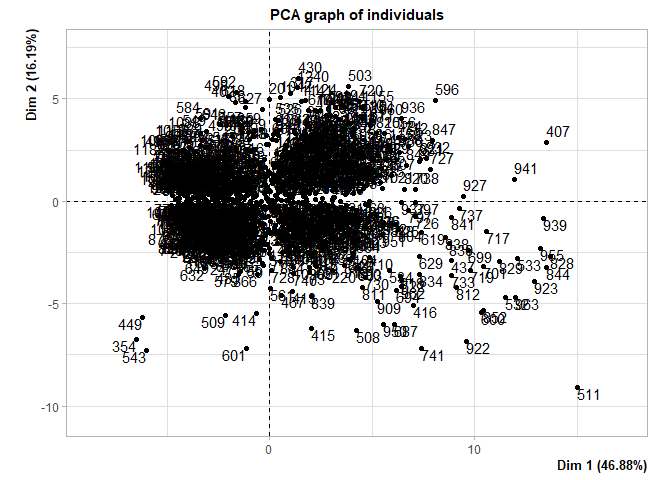

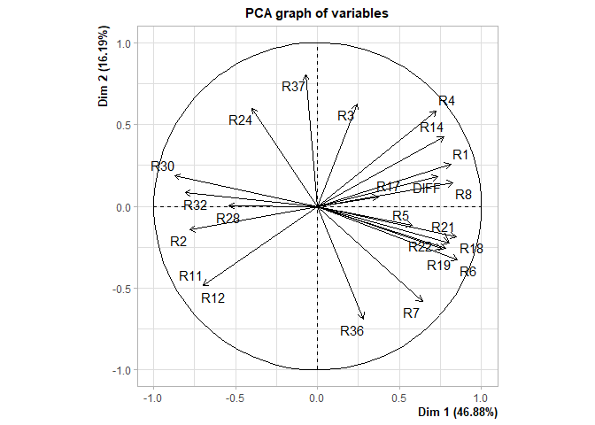

```r
library(FactoMineR)
donnees.acp=PCA(donnee,ncp=23,graph=TRUE)
```

# Choix du nombre de facteurs

Nous avons appris en cours que la règle de Kaiser et l’éboulie des valeurs propres peuvent nous aider à choisir le nombre de facteurs. La règle de Kaiser permet de garder les axes qui correspondent aux valeurs propres supérieures à 1. L’ébouli des valeurs propres sert à garder les axes qui correspondent aux valeurs propres situées avant le point d’inflexion.

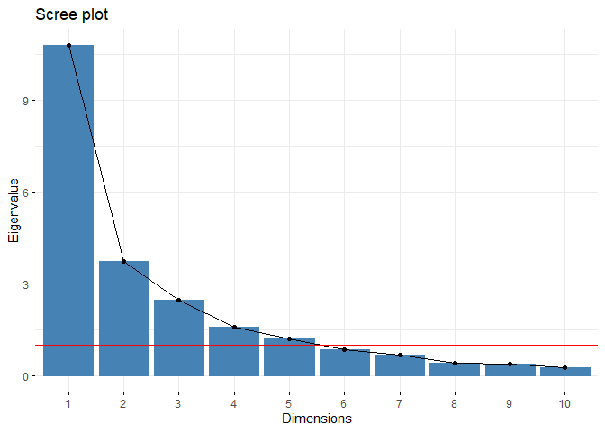

```r
library(factoextra)
vp=donnees.acp$eig %>% data.frame %>% rownames_to_column(var="Composante") %>% as_tibble

fviz_eig(donnees.acp,choice="eigenvalue") +
  geom_hline(yintercept = 1,col="red")
```

Nous pouvons voir sur le premier graphe que les points d’inflexion sont sur le point 6, il y a donc 5 axes qui ont une valeur propre supérieur à 1.

# Pourcentage de variance expliquée cumulée

On utilise le pourcentage de variance expliqué cumulée, autrement appelé règle empirique, pour garder les facteurs qui sont supérieurs à un certain pourcentage. Ici, on prendra 80%. Pour cette méthode, on gardera les facteurs ayant un pourcentage de variance cumulée inférieure ou égale à notre seuil de 80%, jusqu’à avoir dépassé ce seuil.

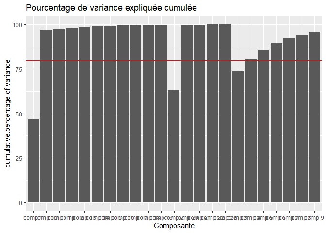

```r
ggplot(vp) + geom_col(aes(x=Composante, y = cumulative.percentage.of.variance)) +
  ggtitle("Pourcentage de variance expliquée cumulée") + geom_hline(aes(yintercept=80),color='red')
```

On peux voir sur ce graphqiue que les 4 premiers facteurs expliquent 80% de la variance cumulée.

# Pourcentage de variance expliquée

Ici, on utilise un seuil de 10%

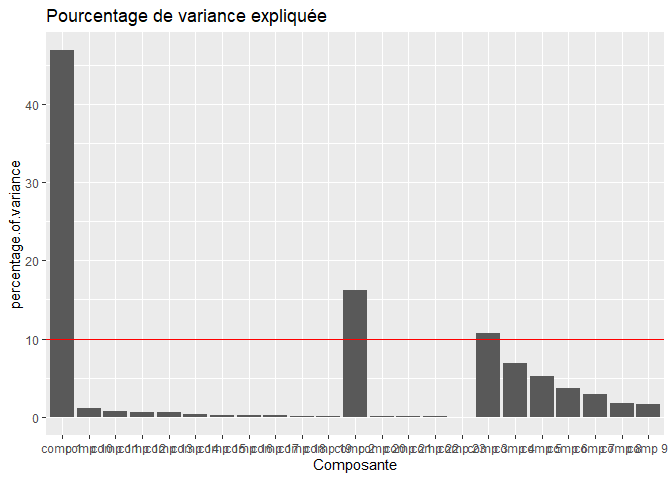

```r
ggplot(vp) + geom_col(aes(x=Composante, y = percentage.of.variance)) +
  ggtitle("Pourcentage de variance expliquée") + geom_hline(aes(yintercept=10),color='red')
```

#Description des axes retenus

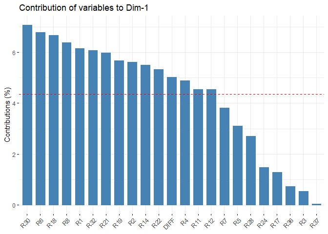

```r
fviz_contrib(donnees.acp,choice="var",axes=1)
```

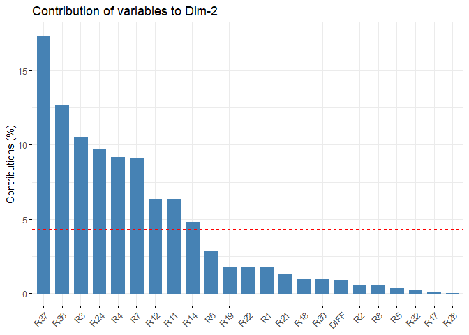

```r
fviz_contrib(donnees.acp,choice="var",axes=2)
```

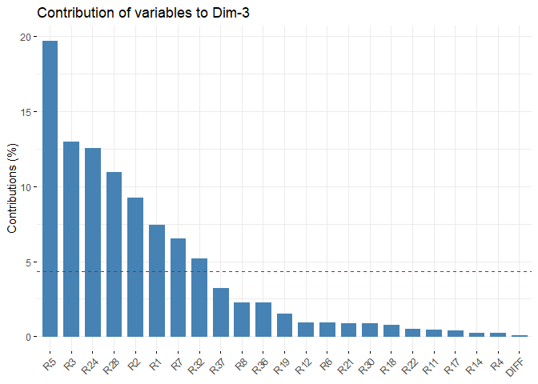

```r
fviz_contrib(donnees.acp,choice="var",axes=3)
```

Sur ces trois graphiques, on remarque que les variables qui contribuent le plus sont :

- L’axe 1 : R30, R6, R18, R8, R21, R32, R1, R19, R2, R22, R14, R4, R11 et R12
- L’axe 2 : R37, R36, R3, R4, R24, R7, R11, R12 et R14
- L’axe 3 : R5, R3, R24, R28, R2, R1, R7 et R32

# Qualité de représentation

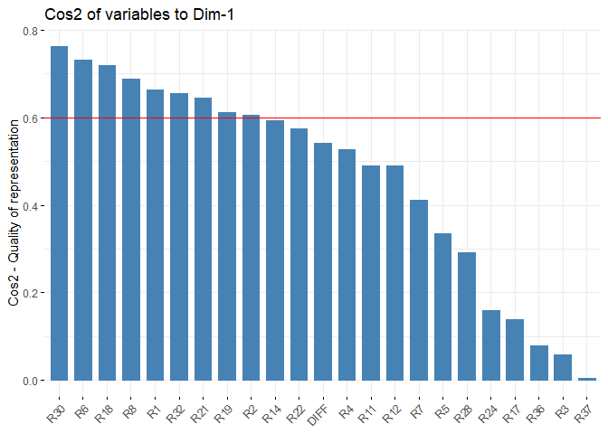

```r
fviz_cos2(donnees.acp,choice="var",axes=1) +
  geom_hline(yintercept = 0.6,col="red")
```

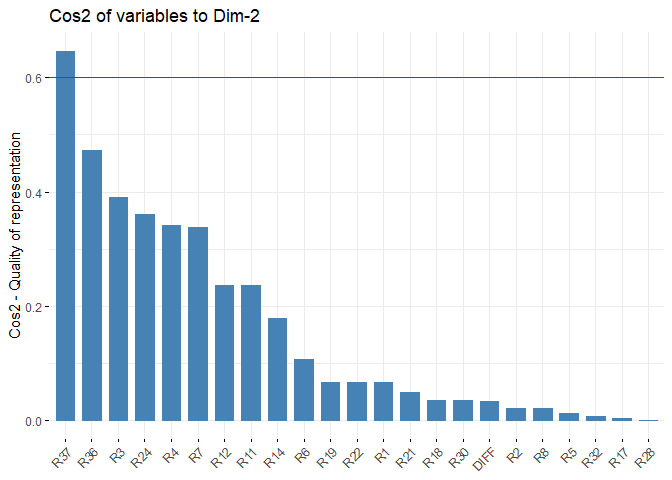

```r
fviz_cos2(donnees.acp,choice="var",axes=2)+
  geom_hline(yintercept = 0.6,col="red")
```

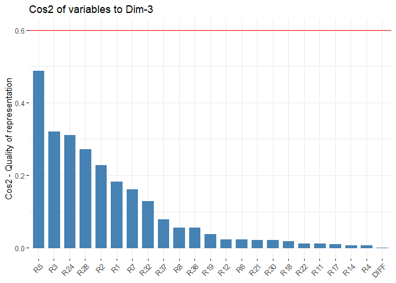

```r
fviz_cos2(donnees.acp,choice="var",axes=3)+
  geom_hline(yintercept = 0.6,col="red")
```

Sur ce graphique avec les cosinus², on remarque que les variables qui contribuent le plus sont :

# Les cercles de corrélation

Grâce à ces cercles de corrélation, nous pourrons voir les différentes variables corrélées

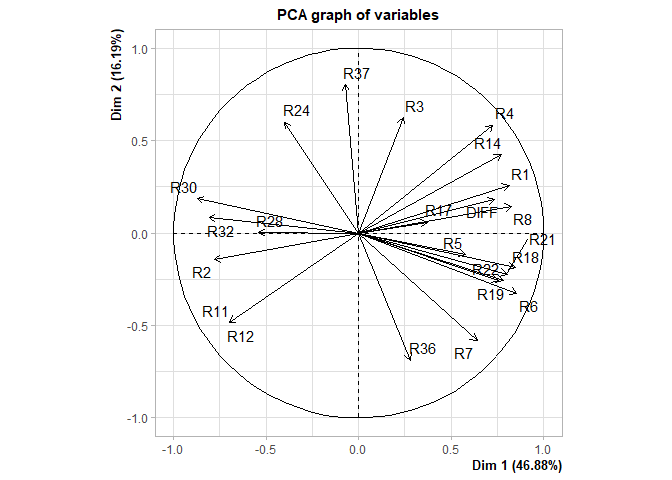

```r
plot(donnees.acp,choix="var",axes=1:2)
```

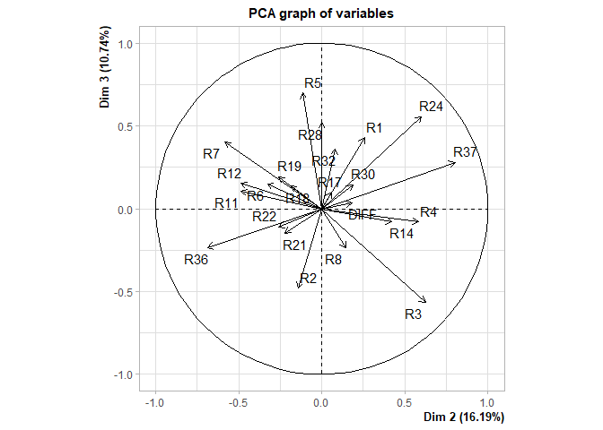

```r
plot(donnees.acp,choix="var",axes=2:3)
```

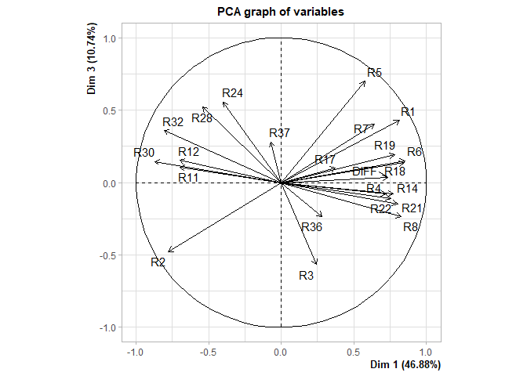

```r
plot(donnees.acp,choix="var",axes=c(1,3))
```

#Interprétation

```r
#plotellipses(donnees.acp)
#plotellipses(donnees.acp,axes=c(1,3))
```

#Corrélation

#Matrice de corrélation

```r
mcor = cor(donnee)
mcor
```

```
##             DIFF           R1          R2          R3           R4           R5
## DIFF  1.00000000  0.647732166 -0.63200923  0.26392192  0.611985059  0.423067148
## R1    0.64773217  1.000000000 -0.90762229  0.12626341  0.754727998  0.818465035
## R2   -0.63200923 -0.907622295  1.00000000  0.02701544 -0.632386521 -0.789519236
## R3    0.26392192  0.126263407  0.02701544  1.00000000  0.648246489 -0.375623938
## R4    0.61198506  0.754727998 -0.63238652  0.64824649  1.000000000  0.264156730
## R5    0.42306715  0.818465035 -0.78951924 -0.37562394  0.264156730  1.000000000
## R6    0.55107920  0.687737801 -0.69076003  0.01097839  0.477508406  0.596593011
## R7    0.38289216  0.557889831 -0.61266009 -0.38667735  0.105678246  0.728911590
## R8    0.58404290  0.617098979 -0.54799843  0.53824987  0.809965522  0.213555780
## R11  -0.55527033 -0.593438053  0.53376479 -0.45125621 -0.729838309 -0.252092576
## R12  -0.56697824 -0.585673700  0.52322865 -0.46279344 -0.721097225 -0.248494570
## R14   0.63150212  0.690890415 -0.59952527  0.46754193  0.812380303  0.332545748
## R17   0.33004861  0.226094609 -0.25832879  0.01542888  0.238551625  0.128448148
## R18   0.57912859  0.625586015 -0.64325225  0.08172325  0.499980384  0.487262954
## R19   0.46997604  0.587966093 -0.56534554  0.00706091  0.404659180  0.517178233
## R21   0.47025843  0.504934974 -0.49731339  0.12089679  0.435702483  0.370621544
## R22   0.41471830  0.489412737 -0.45153058  0.07264834  0.374513128  0.405183122
## R24  -0.21021160 -0.007880474  0.03969318  0.02037770 -0.006127012 -0.009369367
## R28  -0.39043317 -0.300559902  0.26404106 -0.27763225 -0.368157569 -0.136469735
## R30  -0.56442412 -0.600129412  0.56516693 -0.15533490 -0.504288998 -0.458120391
## R32  -0.57522681 -0.517335545  0.49708341 -0.25606177 -0.515164307 -0.326150173
## R36   0.09817485 -0.092668303  0.03853778 -0.22698121 -0.190972627  0.023372175
## R37   0.05260526  0.268949736 -0.17597984  0.25648914  0.322625929  0.130361501
##               R6          R7         R8         R11         R12        R14
## DIFF  0.55107920  0.38289216  0.5840429 -0.55527033 -0.56697824  0.6315021
## R1    0.68773780  0.55788983  0.6170990 -0.59343805 -0.58567370  0.6908904
## R2   -0.69076003 -0.61266009 -0.5479984  0.53376479  0.52322865 -0.5995253
## R3    0.01097839 -0.38667735  0.5382499 -0.45125621 -0.46279344  0.4675419
## R4    0.47750841  0.10567825  0.8099655 -0.72983831 -0.72109722  0.8123803
## R5    0.59659301  0.72891159  0.2135558 -0.25209258 -0.24849457  0.3325457
## R6    1.00000000  0.87897065  0.7759758 -0.42852357 -0.40602090  0.5292252
## R7    0.87897065  1.00000000  0.3999468 -0.13592545 -0.11772587  0.2289454
## R8    0.77597582  0.39994683  1.0000000 -0.66305620 -0.64466999  0.7443480
## R11  -0.42852357 -0.13592545 -0.6630562  1.00000000  0.97857772 -0.8525878
## R12  -0.40602090 -0.11772587 -0.6446700  0.97857772  1.00000000 -0.8382737
## R14   0.52922522  0.22894539  0.7443480 -0.85258778 -0.83827373  1.0000000
## R17   0.15766043  0.08578096  0.1926351 -0.30544990 -0.28818585  0.2759146
## R18   0.81806410  0.68037221  0.6901323 -0.49405441 -0.46526326  0.5569233
## R19   0.76124767  0.68125672  0.5815831 -0.39584374 -0.37620346  0.4642576
```

[output cut: 41 more lines]

```
## R8   -0.387711342 -0.6363833 -0.61299657  0.25109808 -0.13838879
## R11   0.301236568  0.4580213  0.46091183 -0.11133172 -0.22276374
## R12   0.380888131  0.4843052  0.51597859 -0.10485174 -0.23023377
## R14  -0.338275400 -0.5275236 -0.52065024  0.10361970  0.14786653
## R17  -0.002663902 -0.3078354 -0.27498048  0.05439164  0.01425248
## R18  -0.219859365 -0.7105142 -0.61482261  0.35245108 -0.23445606
## R19  -0.176466273 -0.8269998 -0.49810382  0.35211093 -0.21218711
## R21  -0.537558333 -0.7507434 -0.75217080  0.29691539 -0.17886862
## R22  -0.527574122 -0.8250040 -0.68561404  0.29255875 -0.14298451
## R24   0.620718965  0.5326928  0.63663891 -0.59539109  0.68791905
## R28   1.000000000  0.6825819  0.89335952 -0.05430402 -0.04923576
## R30   0.682581869  1.0000000  0.86673369 -0.28109178  0.12291634
## R32   0.893359522  0.8667337  1.00000000 -0.20055704  0.06542747
## R36  -0.054304017 -0.2810918 -0.20055704  1.00000000 -0.75547142
## R37  -0.049235756  0.1229163  0.06542747 -0.75547142  1.00000000
```

On peut voir sur la table les coefficients de corrrélation sont montrés entre les différentes paires possibles de variables.

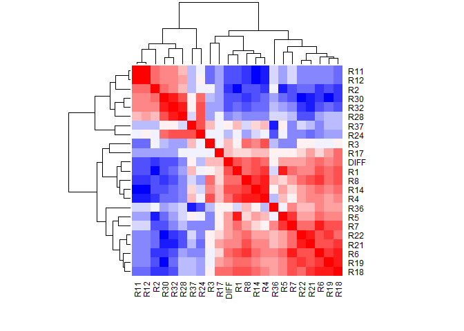

```r
col<- colorRampPalette(c("blue", "white", "red"))(20)
heatmap(x = mcor, col = col, symm = TRUE)
```

X est la matrice de corrélation symm est la valeur logique si x devrait être traité comme symétrique; peut être true si seulement si x est une matrice carrée.

#Table de corrélation

```r
df=as.data.frame(as.table(cor(donnee)))
dff=df[1:23,]
```

On crée un tableau afin de voir mieux en détails nos résultat.

```r
symnum(mcor,abbr.colnames=FALSE)
```

```
##      DIFF R1 R2 R3 R4 R5 R6 R7 R8 R11 R12 R14 R17 R18 R19 R21 R22 R24 R28 R30
## DIFF 1
## R1   ,    1
## R2   ,    *  1
## R3              1
## R4   ,    ,  ,  ,  1
## R5   .    +  ,  .     1
## R6   .    ,  ,     .  .  1
## R7   .    .  ,  .     ,  +  1
## R8   .    ,  .  .  +     ,  .  1
## R11  .    .  .  .  ,     .     ,  1
## R12  .    .  .  .  ,     .     ,  B   1
## R14  ,    ,  .  .  +  .  .     ,  +   +   1
## R17  .                            .           1
## R18  .    ,  ,     .  .  +  ,  ,  .   .   .   ,   1
## R19  .    .  .     .  .  ,  ,  .  .   .   .   .   +   1
## R21  .    .  .     .  .  ,  .  ,  .   .   .   .   ,   ,   1
## R22  .    .  .     .  .  ,  .  .  .   .   .       ,   ,   +   1
## R24                      .  .  .                  .       .   .   1
## R28  .    .        .           .  .   .   .               .   .   ,   1
## R30  .    ,  .     .  .  ,  .  ,  .   .   .   .   ,   +   ,   +   .   ,   1
## R32  .    .  .     .  .  .  .  ,  .   .   .       ,   .   ,   ,   ,   +   +
## R36                      .  .                     .   .           .
## R37                .     .  .                                     ,
##      R32 R36 R37
## DIFF
## R1
## R2
## R3
## R4
## R5
## R6
## R7
## R8
## R11
## R12
## R14
## R17
## R18
## R19
## R21
## R22
## R24
## R28
## R30
## R32  1
## R36      1
## R37      ,   1
## attr(,"legend")
## [1] 0 ' ' 0.3 '.' 0.6 ',' 0.8 '+' 0.9 '*' 0.95 'B' 1
```

Comme on peut le voir dans la légende, les coefficients de corrélation entre 0 et 0.3 sont remplacés par un espace (““); les coefficients de corrélation entre 0.3 et 0.6 sont remplacés par”.”; les coefficients de 0.8 sont remplacé par (+) et de 0.9 par (*)

#Corrélation en format graphique

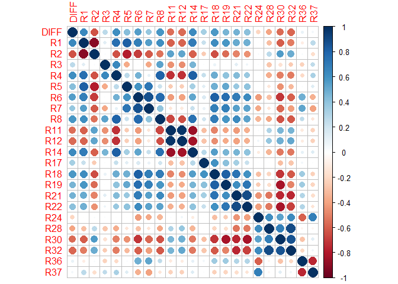

```r
library(corrplot)
corrplot(mcor, method="circle") #Version avec cercle
```

#Modele logistique

L’objectif est de trouver les variables explicatives significatives et le meilleur seuil associé.

```r
model = glm(DIFF~.,data = donnee, family = binomial(logit))
names(model)
```

```
##  [1] "coefficients"      "residuals"         "fitted.values"
##  [4] "effects"           "R"                 "rank"
##  [7] "qr"                "family"            "linear.predictors"
## [10] "deviance"          "aic"               "null.deviance"
## [13] "iter"              "weights"           "prior.weights"
## [16] "df.residual"       "df.null"           "y"
## [19] "converged"         "boundary"          "model"
## [22] "call"              "formula"           "terms"
## [25] "data"              "offset"            "control"
## [28] "method"            "contrasts"         "xlevels"
```

```r
summary(model)
```

```
##
## Call:
## glm(formula = DIFF ~ ., family = binomial(logit), data = donnee)
##
## Deviance Residuals:
##     Min       1Q   Median       3Q      Max
## -4.5135  -0.3737  -0.0845   0.2435   3.0521
##
## Coefficients:
##             Estimate Std. Error z value Pr(>|z|)
## (Intercept) -11.6932     4.3190  -2.707  0.00678 **
## R1           24.5373     8.3017   2.956  0.00312 **
## R2            2.3209     3.5047   0.662  0.50783
## R3            4.3735     1.8713   2.337  0.01943 *
## R4          -10.1236     7.7739  -1.302  0.19283
## R5          -13.4190     8.4799  -1.582  0.11355
## R6           -1.1654     1.6788  -0.694  0.48754
## R7            2.0817     1.9851   1.049  0.29433
## R8           -2.6752     2.0528  -1.303  0.19251
## R11          -1.0817     2.3500  -0.460  0.64529
## R12           1.5486     1.6158   0.958  0.33786
## R14           2.3297     0.7781   2.994  0.00275 **
## R17          39.0878     9.9563   3.926 8.64e-05 ***
## R18         -10.0287    17.5203  -0.572  0.56705
## R19           2.3088    10.8064   0.214  0.83082
## R21           1.1110     3.9905   0.278  0.78070
## R22           1.2595     1.8532   0.680  0.49674
## R24           2.2843     5.6556   0.404  0.68629
## R28         -12.1249    11.6916  -1.037  0.29971
## R30           7.8600    11.1415   0.705  0.48052
## R32          -1.8340    13.9176  -0.132  0.89516
## R36           1.4477     0.4830   2.998  0.00272 **
## R37          -2.1438     1.7772  -1.206  0.22772
## ---
## Signif. codes:  0 '***' 0.001 '**' 0.01 '*' 0.05 '.' 0.1 ' ' 1
##
## (Dispersion parameter for binomial family taken to be 1)
##
##     Null deviance: 1745.1  on 1259  degrees of freedom
## Residual deviance:  658.5  on 1237  degrees of freedom
## AIC: 704.5
##
## Number of Fisher Scoring iterations: 8
```

```r
exp(cbind(coef(model), confint(model)))
```

```
##                                 2.5 %       97.5 %
## (Intercept) 8.350014e-06 1.691609e-09 3.372350e-02
## R1          4.533401e+10 2.091101e+03 6.542909e+16
## R2          1.018484e+01 1.195099e-02 9.458881e+03
## R3          7.932149e+01 1.744656e+00 2.807601e+03
## R4          4.012044e-05 8.072616e-11 3.496516e+02
## R5          1.486664e-06 4.561741e-13 3.048518e+01
## R6          3.117844e-01 1.389808e-02 1.289689e+01
## R7          8.018147e+00 1.413686e-01 4.061261e+02
## R8          6.889599e-02 9.545196e-04 3.434675e+00
## R11         3.390131e-01 3.699604e-03 2.479931e+01
## R12         4.704857e+00 2.521155e-01 1.075924e+02
## R14         1.027438e+01 2.440877e+00 5.124917e+01
## R17         9.454128e+16 3.573787e+08 3.298491e+25
## R18         4.411383e-05 3.796154e-20 1.409228e+10
## R19         1.006222e+01 1.412752e-09 8.870157e+08
## R21         3.037412e+00 1.949257e-03 1.010670e+04
## R22         3.523548e+00 1.322911e-01 1.440473e+02
## R24         9.818423e+00 1.471723e-04 6.316092e+05
## R28         5.422755e-06 9.378860e-16 6.042859e+04
## R30         2.591541e+03 5.716757e-07 8.290352e+11
## R32         1.597786e-01 5.577588e-14 4.214574e+10
## R36         4.253171e+00 1.669338e+00 1.116181e+01
## R37         1.172137e-01 2.810966e-03 3.165663e+00
```

Avec cette fonction, on peut voir les coefficients du modèle et leurs intervalles de confiance.

#Apprentissage vs Test

Nous allons echantilloner notre base pour avoir un échantillon d’apprentissage. On fait un tirage aléatoire et sans remise pour que 80% (seuil de base) des données constitue l’échantillon d’apprentissage. Et 20% l’échantillon de test.

```r
set.seed(200)
id_appren = sort(sample(nrow(donnee), floor(nrow(donnee) * 0.80)))

donnee_appren <- donnee[id_appren, ] #donnée apprentissage

donnees_test <- donnee[-id_appren, ]# Echantillon de test


summary(donnee_appren)
```

```
##       DIFF              R1               R2               R3
##  Min.   :0.0000   Min.   :0.1190   Min.   :0.0000   Min.   :-1.5060
##  1st Qu.:0.0000   1st Qu.:0.3405   1st Qu.:0.3187   1st Qu.: 0.2230
##  Median :0.0000   Median :0.5285   Median :0.5775   Median : 0.3646
##  Mean   :0.4792   Mean   :0.5854   Mean   :0.5220   Mean   : 0.3787
##  3rd Qu.:1.0000   3rd Qu.:0.7853   3rd Qu.:0.7542   3rd Qu.: 0.5216
##  Max.   :1.0000   Max.   :3.4940   Max.   :0.9980   Max.   : 0.9999
##        R4                R5                R6               R7
##  Min.   :-0.4940   Min.   :0.00006   Min.   :0.1800   Min.   :0.00005
##  1st Qu.: 0.0804   1st Qu.:0.20375   1st Qu.:0.5600   1st Qu.:0.32275
##  Median : 0.1635   Median :0.32900   Median :0.9055   Median :0.54450
##  Mean   : 0.2294   Mean   :0.35377   Mean   :1.0408   Mean   :0.64502
##  3rd Qu.: 0.3277   3rd Qu.:0.46825   3rd Qu.:1.3582   3rd Qu.:0.86400
##  Max.   : 1.1114   Max.   :2.79200   Max.   :4.3620   Max.   :3.11700
##        R8               R11               R12                R14
##  Min.   :-0.9330   Min.   :-0.9060   Min.   :-1.16300   Min.   :-0.6850
##  1st Qu.: 0.1370   1st Qu.:-0.0145   1st Qu.:-0.01798   1st Qu.: 0.2159
##  Median : 0.2820   Median : 0.2881   Median : 0.43785   Median : 0.4610
##  Mean   : 0.3880   Mean   : 0.2632   Mean   : 0.43170   Mean   : 0.7006
##  3rd Qu.: 0.5579   3rd Qu.: 0.5435   3rd Qu.: 0.86800   3rd Qu.: 1.0246
##  Max.   : 1.8494   Max.   : 2.2959   Max.   : 3.97150   Max.   : 5.1712
##       R17               R18               R19               R21
##  Min.   :0.00599   Min.   :0.00169   Min.   :0.01700   Min.   :0.00663
##  1st Qu.:0.04487   1st Qu.:0.02955   1st Qu.:0.09805   1st Qu.:0.08753
##  Median :0.06210   Median :0.05680   Median :0.15600   Median :0.17300
##  Mean   :0.06428   Mean   :0.07049   Mean   :0.18115   Mean   :0.28285
##  3rd Qu.:0.08153   3rd Qu.:0.09530   3rd Qu.:0.23600   3rd Qu.:0.34125
##  Max.   :0.12400   Max.   :0.30000   Max.   :1.14200   Max.   :5.07900
##       R22                R24              R28              R30
##  Min.   : 0.04939   Min.   :0.0141   Min.   :0.0347   Min.   :-1.05900
##  1st Qu.: 0.28305   1st Qu.:0.1378   1st Qu.:0.2577   1st Qu.: 0.05196
##  Median : 0.49695   Median :0.1880   Median :0.3280   Median : 0.16045
##  Mean   : 0.70072   Mean   :0.1982   Mean   :0.3217   Mean   : 0.14020
##  3rd Qu.: 0.81870   3rd Qu.:0.2460   3rd Qu.:0.3890   3rd Qu.: 0.26395
##  Max.   :13.67300   Max.   :0.7460   Max.   :0.5810   Max.   : 0.51320
##       R32               R36              R37
##  Min.   :-0.1620   Min.   :0.1180   Min.   :0.1600
##  1st Qu.: 0.1710   1st Qu.:0.7735   1st Qu.:0.4630
##  Median : 0.2676   Median :1.0750   Median :0.5780
##  Mean   : 0.2510   Mean   :1.1634   Mean   :0.6185
##  3rd Qu.: 0.3387   3rd Qu.:1.4572   3rd Qu.:0.7292
##  Max.   : 0.5626   Max.   :5.0430   Max.   :2.3490
```

```r
str(donnee_appren)
```

```
## 'data.frame':    1008 obs. of  23 variables:
##  $ DIFF: int  0 0 0 0 0 0 0 0 0 0 ...
##  $ R1  : num  0.449 0.45 0.332 0.363 0.44 0.306 0.717 0.566 0.384 0.305 ...
##  $ R2  : num  0.622 0.617 0.819 0.733 0.65 0.755 0.32 0.465 0.707 0.7 ...
##  $ R3  : num  0.255 0.241 0.557 0.36 0.314 ...
##  $ R4  : num  0.114 0.108 0.185 0.13 0.138 ...
##  $ R5  : num  0.334 0.341 0.147 0.232 0.302 0.225 0.601 0.499 0.256 0.298 ...
##  $ R6  : num  0.785 0.518 0.7 0.773 0.846 0.709 0.894 0.863 0.846 0.674 ...
##  $ R7  : num  0.585 0.393 0.31 0.495 0.58 0.523 0.748 0.761 0.563 0.658 ...
##  $ R8  : num  0.2 0.125 0.39 0.278 0.266 ...
##  $ R11 : num  0.663 0.71 0.414 0.466 0.771 ...
##  $ R12 : num  1.37 1.253 0.637 1.07 1.475 ...
##  $ R14 : num  0.232 0.15 0.485 0.373 0.256 ...
##  $ R17 : num  0.0884 0.0671 0.0445 0.0621 0.0489 0.0243 0.0352 0.0879 0.0668 0.0694 ...
##  $ R18 : num  0.0694 0.0348 0.0311 0.048 0.0414 0.0173 0.0315 0.0758 0.0565 0.0468 ...
##  $ R19 : num  0.166 0.136 0.103 0.108 0.127 0.0652 0.129 0.24 0.171 0.126 ...
##  $ R21 : num  0.134 0.0802 0.089 0.0851 0.0838 0.039 0.0784 0.163 0.155 0.106 ...
##  $ R22 : num  0.322 0.313 0.294 0.191 0.257 ...
##  $ R24 : num  0.295 0.365 0.166 0.265 0.257 0.191 0.322 0.305 0.166 0.2 ...
##  $ R28 : num  0.475 0.434 0.35 0.475 0.475 0.443 0.401 0.464 0.365 0.443 ...
##  $ R30 : num  0.35 0.298 0.247 0.376 0.367 ...
##  $ R32 : num  0.431 0.399 0.319 0.431 0.431 ...
##  $ R36 : num  0.886 0.351 1.3 1.385 0.886 ...
##  $ R37 : num  0.572 0.867 0.475 0.47 0.52 0.431 0.803 0.656 0.454 0.453 ...
```

```r
model_appren=glm(DIFF~., data = donnee_appren, family = binomial)
summary(model_appren)
```

```
##
## Call:
## glm(formula = DIFF ~ ., family = binomial, data = donnee_appren)
##
## Deviance Residuals:
##     Min       1Q   Median       3Q      Max
## -4.3663  -0.3527  -0.0837   0.2472   3.0020
##
## Coefficients:
##             Estimate Std. Error z value Pr(>|z|)
## (Intercept) -12.9795     4.6421  -2.796  0.00517 **
## R1           22.8884     8.7472   2.617  0.00888 **
## R2            3.1449     3.6476   0.862  0.38858
## R3            5.2302     2.0492   2.552  0.01070 *
## R4           -7.4158     8.3139  -0.892  0.37240
## R5           -9.3228     9.0095  -1.035  0.30077
## R6           -0.6384     2.4927  -0.256  0.79787
## R7            0.7575     2.6186   0.289  0.77238
## R8           -3.6307     2.8044  -1.295  0.19545
## R11          -1.1579     2.5358  -0.457  0.64794
## R12           1.3801     1.7138   0.805  0.42065
## R14           1.7394     0.8565   2.031  0.04227 *
## R17          30.6742    11.5993   2.644  0.00818 **
## R18          -4.0256    18.2743  -0.220  0.82565
## R19           5.8995    11.6437   0.507  0.61239
## R21           0.3263     4.2340   0.077  0.93858
## R22           1.9591     2.0164   0.972  0.33125
## R24           2.9535     6.3413   0.466  0.64140
## R28         -14.3887    12.4871  -1.152  0.24920
## R30          13.5769    11.6995   1.160  0.24586
## R32          -3.2976    14.4416  -0.228  0.81938
## R36           1.6997     0.5392   3.152  0.00162 **
## R37          -2.7687     2.0248  -1.367  0.17151
## ---
## Signif. codes:  0 '***' 0.001 '**' 0.01 '*' 0.05 '.' 0.1 ' ' 1
##
## (Dispersion parameter for binomial family taken to be 1)
##
##     Null deviance: 1395.63  on 1007  degrees of freedom
## Residual deviance:  530.84  on  985  degrees of freedom
## AIC: 576.84
##
## Number of Fisher Scoring iterations: 8
```

#Selection de variables

On cherche à trouver un sous ensemble de variables suffisantes pour expliquer les difficultés financières des exploitations agricoles.

```r
model_AIC=step(model_appren,direction="both",trace=TRUE)
```

```
## Start:  AIC=576.84
## DIFF ~ R1 + R2 + R3 + R4 + R5 + R6 + R7 + R8 + R11 + R12 + R14 +
##     R17 + R18 + R19 + R21 + R22 + R24 + R28 + R30 + R32 + R36 +
##     R37
##
##        Df Deviance    AIC
## - R21   1   530.85 574.85
## - R18   1   530.89 574.89
## - R32   1   530.90 574.90
## - R6    1   530.90 574.90
## - R7    1   530.92 574.92
## - R24   1   531.06 575.06
## - R11   1   531.07 575.07
## - R19   1   531.08 575.08
## - R2    1   531.58 575.58
## - R12   1   531.59 575.59
## - R4    1   531.59 575.59
## - R22   1   531.81 575.81
## - R5    1   531.89 575.89
## - R30   1   532.05 576.05
## - R28   1   532.12 576.12
## - R8    1   532.68 576.68
## <none>      530.84 576.84
## - R37   1   532.97 576.97
## - R14   1   535.59 579.59
## - R3    1   536.77 580.77
## - R17   1   537.80 581.80
## - R1    1   538.94 582.94
## - R36   1   540.95 584.95
##
## Step:  AIC=574.85
## DIFF ~ R1 + R2 + R3 + R4 + R5 + R6 + R7 + R8 + R11 + R12 + R14 +
##     R17 + R18 + R19 + R22 + R24 + R28 + R30 + R32 + R36 + R37
##
##        Df Deviance    AIC
## - R18   1   530.89 572.89
## - R6    1   530.91 572.91
## - R32   1   530.93 572.93
## - R7    1   530.93 572.93
## - R19   1   531.08 573.08
```

[output cut: 321 more lines]

```
## + R7    1   535.71 559.71
## + R32   1   535.72 559.72
## + R6    1   535.73 559.73
## + R18   1   535.74 559.74
## + R21   1   535.74 559.74
## - R14   1   541.63 561.63
## - R37   1   542.21 562.21
## - R30   1   543.63 563.63
## - R22   1   545.21 565.21
## - R8    1   546.88 566.88
## - R36   1   548.47 568.47
## - R28   1   551.53 571.53
## - R3    1   558.72 578.72
## - R17   1   564.71 584.71
## - R1    1   642.30 662.30
```

```r
summary(model_AIC)
```

```
##
## Call:
## glm(formula = DIFF ~ R1 + R3 + R8 + R14 + R17 + R22 + R28 + R30 +
##     R36 + R37, family = binomial, data = donnee_appren)
##
## Deviance Residuals:
##     Min       1Q   Median       3Q      Max
## -4.2462  -0.3595  -0.0941   0.2609   3.0582
##
## Coefficients:
##             Estimate Std. Error z value Pr(>|z|)
## (Intercept)  -9.9524     1.6129  -6.170 6.82e-10 ***
## R1           11.1091     1.2135   9.155  < 2e-16 ***
## R3            6.7624     1.3553   4.990 6.05e-07 ***
## R8           -3.8009     1.0772  -3.529 0.000418 ***
## R14           1.2324     0.5364   2.298 0.021581 *
## R17          30.9474     6.0003   5.158 2.50e-07 ***
## R22           2.4138     0.8815   2.738 0.006178 **
## R28         -10.2199     2.6410  -3.870 0.000109 ***
## R30           9.5820     3.5334   2.712 0.006691 **
## R36           1.4660     0.4121   3.558 0.000374 ***
## R37          -2.4454     1.0460  -2.338 0.019396 *
## ---
## Signif. codes:  0 '***' 0.001 '**' 0.01 '*' 0.05 '.' 0.1 ' ' 1
##
## (Dispersion parameter for binomial family taken to be 1)
##
##     Null deviance: 1395.63  on 1007  degrees of freedom
## Residual deviance:  535.74  on  997  degrees of freedom
## AIC: 557.74
##
## Number of Fisher Scoring iterations: 8
```

On voit que notre code nous donne R1 + R3 + R8 + R14 + R17 + R22 + R28 + R30 + R36 + R37 comme variables suffisantes à expliquer les difficultés financières des exploitations agricoles.

#Interprétation

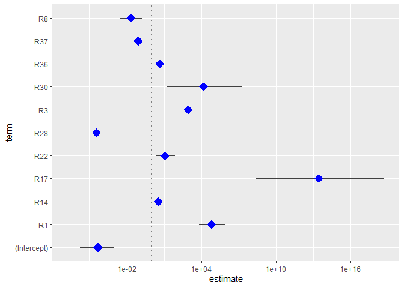

```r
#oddss ratio
library(GGally)
ggcoef(model_AIC, exponentiate = TRUE, color = "blue", size = 5, shape = 18)
```

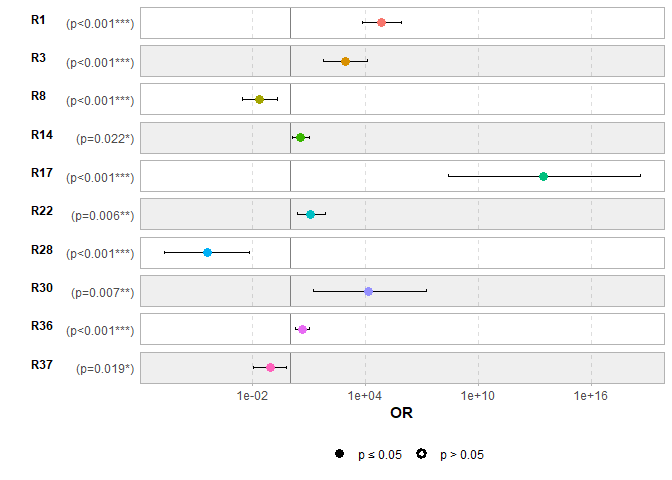

```r
ggcoef_model(model_AIC, exponentiate = TRUE)
```

```r
exp(coef(model_AIC))
```

```
##  (Intercept)           R1           R3           R8          R14          R17
## 4.761543e-05 6.677723e+04 8.647468e+02 2.235157e-02 3.429391e+00 2.756082e+13
##          R22          R28          R30          R36          R37
## 1.117654e+01 3.643908e-05 1.450082e+04 4.331885e+00 8.669304e-02
```

```r
exp(confint(model_AIC))
```

```
##                    2.5 %       97.5 %
## (Intercept) 1.867921e-06 1.045516e-03
## R1          6.582526e+03 7.766161e+05
## R3          5.912836e+01 1.229028e+04
## R8          2.785687e-03 1.957294e-01
## R14         1.254902e+00 1.030291e+01
## R17         2.643934e+08 4.468471e+18
## R22         2.231937e+00 7.578876e+01
## R28         1.990431e-07 6.165022e-03
## R30         1.662365e+01 1.803570e+07
## R36         1.937560e+00 9.795206e+00
## R37         1.015960e-02 5.902974e-01
```

Dans le premier graphique, plus les losanges sont écartés de 1, plus les variables sont importantes. Dans le deuxième graphique, nous avons les mêmes résultats que les graphique précedents, avec les p-valeurs en plus à côté

```r
#library(ggeffects)
#library(effects)
#ggeffect(model_AIC)
#plot(ggeffect(model_AIC))
#forest_model(model_AIC)
#cowplot::plot_grid(plotlist = plot(ggeffect(model_AIC)))
```

```r
#library(effects)
#plot(allEffects(model_AIC))
```

#Echantillon test

```r
ystar = predict(model_AIC, newdata = donnees_test)

muhat= predict(model_AIC, newdata = donnees_test, type="response")

muhat
```

```
##           9          16          20          22          26          27
## 0.049602838 0.210837666 0.284699158 0.176807595 0.729335695 0.216857176
##          30          31          37          41          42          44
## 0.238882103 0.003903522 0.061690499 0.019667594 0.153255234 0.143362613
##          47          49          50          59          75          77
## 0.138333052 0.070532219 0.031958645 0.791313791 0.110865304 0.774475896
##          79          83          84          86          90          93
## 0.789664700 0.624388933 0.769490461 0.699594915 0.380323150 0.984034559
##         104         105         106         107         108         109
## 0.994412390 0.801613665 0.801912973 0.053588509 0.185601607 0.977955934
##         113         119         122         132         133         139
## 0.841565521 0.357150810 0.049662409 0.146658892 0.092627023 0.091364845
##         145         156         160         161         164         172
## 0.004581726 0.448204597 0.179160008 0.137077118 0.106128065 0.087644749
##         175         183         185         186         190         198
## 0.828175300 0.901549049 0.085637275 0.778402087 0.981616026 0.948398313
##         199         201         205         206         210         220
## 0.551166313 0.988564498 0.286886605 0.848111740 0.903865133 0.977523630
##         223         224         229         231         236         237
## 0.176076844 0.168417039 0.746435454 0.997744846 0.199892165 0.293089531
##         247         250         251         252         260         273
## 0.049088266 0.102945740 0.005501178 0.238064706 0.018057172 0.052595774
##         278         291         298         299         321         322
## 0.205567520 0.843568759 0.720675132 0.976213544 0.108965002 0.995023680
##         337         338         339         345         356         357
## 0.898474950 0.928914619 0.175373536 0.328992809 0.452571912 0.544838182
##         365         372         385         389         403         408
## 0.070780703 0.572131132 0.053980790 0.122104738 0.116777344 0.885957163
##         409         411         415         427         435         440
## 0.999188732 0.997337415 0.402030562 0.923200687 0.991764510 0.977753973
##         444         448         467         471         474         476
## 0.071333278 0.389794365 0.253490016 0.020095261 0.225485464 0.062796269
##         481         486         489         494         502         504
## 0.101032629 0.794197632 0.582724722 0.004288827 0.259943278 0.999174770
##         509         512         518         532         536         552
## 0.099583497 0.773646030 0.557958236 0.994791574 0.999171924 0.007270240
##         557         561         568         569         572         573
## 0.034522711 0.173549373 0.153471157 0.115566728 0.054656878 0.012427999
##         583         591         601         612         613         621
## 0.134400572 0.861210195 0.297899325 0.942821366 0.991557711 0.867839151
```

[output cut: 29 more lines]

```
## 0.012573151 0.091915067 0.156186012 0.026624914 0.010327555 0.174177549
##        1083        1085        1091        1092        1094        1102
## 0.008227687 0.005989561 0.080813895 0.248807139 0.009848674 0.052324168
##        1110        1116        1119        1121        1125        1131
## 0.139112832 0.698408375 0.969283783 0.998756245 0.964017309 0.917913577
##        1140        1143        1144        1168        1170        1177
## 0.869566314 0.995382942 0.704428776 0.144011384 0.456402262 0.079533754
##        1181        1189        1192        1194        1196        1197
## 0.112795069 0.020087121 0.003229317 0.029366028 0.081205914 0.010838523
##        1199        1201        1206        1208        1209        1214
## 0.039520079 0.046677831 0.063695054 0.009841976 0.008355392 0.999690170
##        1217        1220        1223        1231        1232        1237
## 0.986890961 0.993034333 0.988147894 0.981478344 0.996959146 0.165096246
##        1238        1243        1245        1253        1258        1259
## 0.993134361 0.937177153 0.876079248 0.991541952 0.999607708 0.699876267
```

```r
yhat = factor(as.numeric(muhat > 0.5))
yhat
```

```
##   [1] 0 0 0 0 1 0 0 0 0 0 0 0 0 0 0 1 0 1 1 1 1 1 0 1 1 1 1 0 0 1 1 0 0 0 0 0 0
##  [38] 0 0 0 0 0 1 1 0 1 1 1 1 1 0 1 1 1 0 0 1 1 0 0 0 0 0 0 0 0 0 1 1 1 0 1 1 1
##  [75] 0 0 0 1 0 1 0 0 0 1 1 1 0 1 1 1 0 0 0 0 0 0 0 1 1 0 0 1 0 1 1 1 1 0 0 0 0
## [112] 0 0 0 0 1 0 1 1 1 1 1 1 0 1 0 0 0 0 0 1 1 1 1 1 1 1 0 0 0 0 0 0 0 0 0 0 0
## [149] 0 0 0 1 1 1 1 1 1 1 1 1 1 1 1 1 0 0 0 0 0 0 0 1 1 1 1 1 1 1 1 1 1 1 1 1 0
## [186] 0 0 0 0 0 0 0 0 0 0 0 0 1 0 1 1 1 1 1 0 0 0 0 0 0 0 0 0 0 0 0 0 1 1 1 1 1
## [223] 1 1 1 0 0 0 0 0 0 0 0 0 0 0 0 0 0 1 1 1 1 1 1 0 1 1 1 1 1 1
## Levels: 0 1
```

```r
mat.conf <- addmargins(table(Predicted=yhat,Actual=donnees_test$DIFF))
mat.conf
```

```
##          Actual
## Predicted   0   1 Sum
##       0   119  20 139
##       1     9 104 113
##       Sum 128 124 252
```

```r
mat.conf[1, 1:2]/mat.conf[3, 1:2]
```

```
##         0         1
## 0.9296875 0.1612903
```

```r
(mat.conf[1, 1] + mat.conf[2, 2])/sum(mat.conf[3, 1:2])
```

```
## [1] 0.8849206
```

```r
c(mat.conf[1, 1]/mat.conf[3, 1],mat.conf[2, 2]/mat.conf[3, 2])
```

```
## [1] 0.9296875 0.8387097
```

```r
pred = data.frame(Actual = donnees_test$DIFF, Predicted = yhat)
cible = pred %>% filter(Actual == 1)
100*sum(cible$Actual != cible$Predicted)/nrow(cible)
```

```
## [1] 16.12903
```

```r
#library(ROCR)
#pred_test <- prediction(muhat, donnee_test$DIFF)
#perf_test <- performance(pred_test, measure = "tpr", x.measure = "fpr")
#plot(perf_test, colorize = T, print.cutoffs.at = seq(0, 1,by = 0.1), text.adj = c(1.2, 1.2), lwd = 3)
```

```r
#perf_test_auc= performance(pred_test, "auc")
#perf_test_auc@y.values[[1]]
```

#Validation croisée

La validation croisée va nous permettre d’utiliser l’intégralité de notre base de données pour l’entraînement et pour la validation. On va donc diviser les données en K groupes et pour chaque groupe, créer un modèle glm.

```r
library(boot)
res.glm <- glm(model_AIC$formula , family = binomial(link = "logit"),data = donnee)
cout <- function(r, pi = 0) mean(abs(r - pi) > 0.5)
res.cv <- cv.glm(donnee, res.glm,cout, K = 10)

res.cv$delta[1]
```

```
## [1] 0.1126984
```